# p8105_hw6_raj2152

Rachelle Juan

12/2/2021

## Problem 1

Load the data

```r
bwt_df = read_csv("./data/birthweight.csv") %>%
  janitor::clean_names()
```

Clean the data: drop missings, convert numeric to factor for categorical variables, set reference group for categorical variables using `fct_inseq`. There were no missing values.

```r
bwt_df =
  bwt_df %>%
  drop_na() %>%
  mutate(
    babysex = factor(babysex),
    frace = factor(frace),
    malform = factor(malform),
    mrace = factor(mrace)
  ) %>%
  mutate(
    babysex = fct_inseq(babysex),
    frace = fct_inseq(frace),
    malform = fct_inseq(malform),
    mrace = fct_inseq(mrace)
  )
```

**Regression model for birthweight**: I considered birthweight as an outcome that may depend on mother’s age at delivery, previous number of low birth weight babies, and average number of cigarettes smoked per day during pregnancy. This model is based on a hypothesized understanding of the variables that influence baby’s birthweight from the perspective of the mother’s demographics and health. I started with fitting a linear model.

```r
fit = lm(bwt ~ momage + pnumlbw + smoken, data = bwt_df)
summary(fit)
```

```
##
## Call:
## lm(formula = bwt ~ momage + pnumlbw + smoken, data = bwt_df)
##
## Residuals:
##      Min       1Q   Median       3Q      Max
## -2538.53  -288.95    22.05   325.09  1695.05
##
## Coefficients: (1 not defined because of singularities)
##             Estimate Std. Error t value Pr(>|t|)
## (Intercept) 2757.689     40.916  67.399  < 2e-16 ***
## momage        18.792      1.985   9.469  < 2e-16 ***
## pnumlbw           NA         NA      NA       NA
## smoken        -5.971      1.039  -5.747 9.68e-09 ***
## ---
## Signif. codes:  0 '***' 0.001 '**' 0.01 '*' 0.05 '.' 0.1 ' ' 1
##
## Residual standard error: 505.6 on 4339 degrees of freedom
## Multiple R-squared:  0.02585,    Adjusted R-squared:  0.0254
## F-statistic: 57.57 on 2 and 4339 DF,  p-value: < 2.2e-16
```

```r
fit %>%
  broom::tidy()
```

```
## # A tibble: 4 × 5
##   term        estimate std.error statistic   p.value
##   <chr>          <dbl>     <dbl>     <dbl>     <dbl>
## 1 (Intercept)  2758.       40.9      67.4   0
## 2 momage         18.8       1.98      9.47  4.50e-21
## 3 pnumlbw        NA        NA        NA    NA
## 4 smoken         -5.97      1.04     -5.75  9.68e- 9
```

We see that, on average, a 1-year increase in mother’s age in years significantly increases baby’s birthweight by 18.8 grams. `smoken` was also significant in the model (p<0.05). My final model will remove `pnumlbw` since all values in this column are zero.

```r
model1 = lm(bwt ~ momage + smoken, data = bwt_df)
summary(model1)
```

```
##
## Call:
## lm(formula = bwt ~ momage + smoken, data = bwt_df)
##
## Residuals:
##      Min       1Q   Median       3Q      Max
## -2538.53  -288.95    22.05   325.09  1695.05
##
## Coefficients:
##             Estimate Std. Error t value Pr(>|t|)
## (Intercept) 2757.689     40.916  67.399  < 2e-16 ***
## momage        18.792      1.985   9.469  < 2e-16 ***
## smoken        -5.971      1.039  -5.747 9.68e-09 ***
## ---
## Signif. codes:  0 '***' 0.001 '**' 0.01 '*' 0.05 '.' 0.1 ' ' 1
##
## Residual standard error: 505.6 on 4339 degrees of freedom
## Multiple R-squared:  0.02585,    Adjusted R-squared:  0.0254
## F-statistic: 57.57 on 2 and 4339 DF,  p-value: < 2.2e-16
```

```r
model1 %>%
  broom::tidy()
```

```
## # A tibble: 3 × 5
##   term        estimate std.error statistic  p.value
##   <chr>          <dbl>     <dbl>     <dbl>    <dbl>
## 1 (Intercept)  2758.       40.9      67.4  0
## 2 momage         18.8       1.98      9.47 4.50e-21
## 3 smoken         -5.97      1.04     -5.75 9.68e- 9
```

In this new model, `momage` and `smoken` are reliable predictors of `bwt`.

The plot of residuals for `momage` and `smoken` show an equal distribution of the residuals, therefore, there is no violation of our model assumptions. We see some outliers of `smoken`.

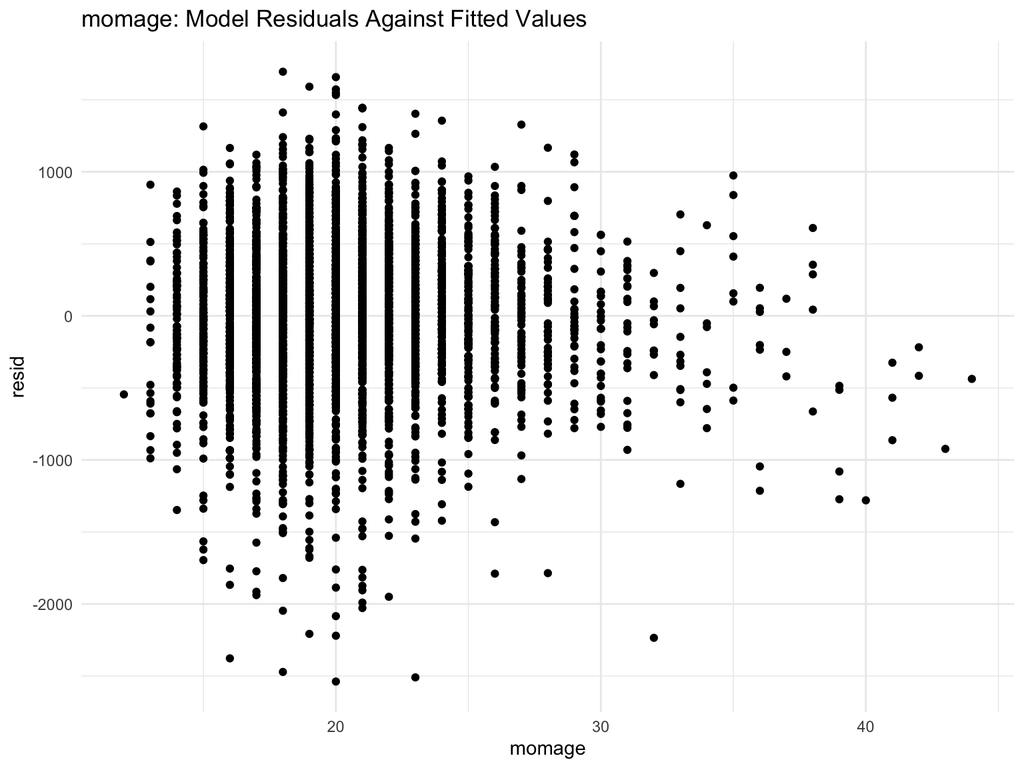

```r
bwt_df %>%
  modelr::add_residuals(model1) %>%
  ggplot(aes(x = momage, y = resid)) +
  geom_point() +
  labs(
    title = "momage: Model Residuals Against Fitted Values"
  )
```

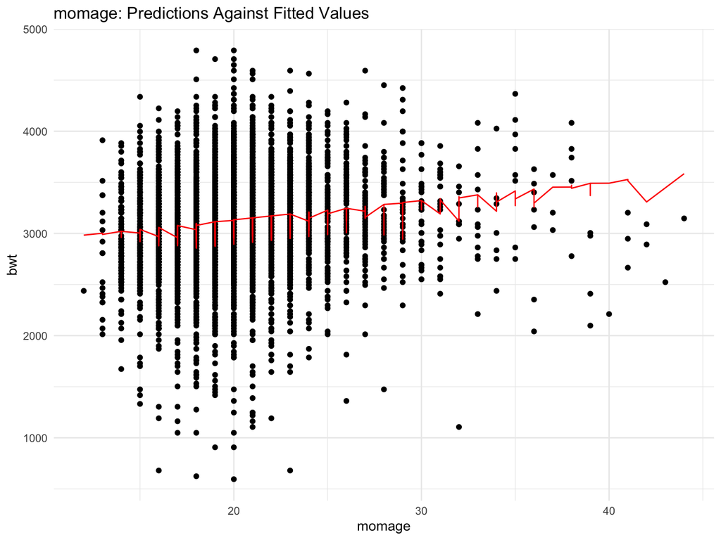

```r
bwt_df %>%
  modelr::add_predictions(model1) %>%
  ggplot(aes(x = momage, y = bwt)) + geom_point() +
  geom_line(aes(y = pred), color = "red") +
  labs(
    title = "momage: Predictions Against Fitted Values"
  )
```

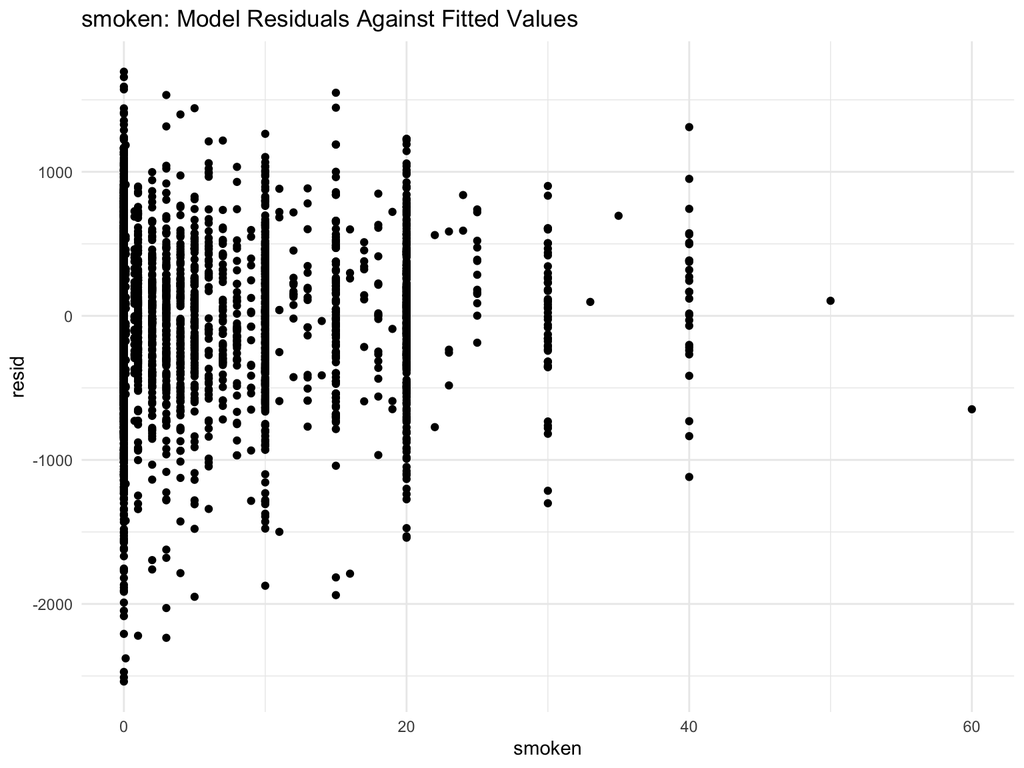

```r
bwt_df %>%
  modelr::add_residuals(model1) %>%
  ggplot(aes(x = smoken, y = resid)) +
  geom_point() +
  labs(
    title = "smoken: Model Residuals Against Fitted Values"
  )
```

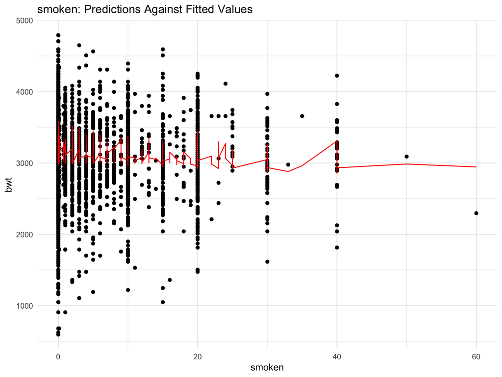

```r
bwt_df %>%
  modelr::add_predictions(model1) %>%
  ggplot(aes(x = smoken, y = bwt)) + geom_point() +
  geom_line(aes(y = pred), color = "red") +
  labs(
    title = "smoken: Predictions Against Fitted Values"
  )
```

### Compare to other models

```r
model2 = lm(bwt ~ blength + gaweeks, data = bwt_df)
model3 = lm(bwt ~ bhead * blength * babysex, data = bwt_df)
```

Cross-validation

```r
cv_df = crossv_mc(bwt_df, 100)

cv_df =
  cv_df %>%
  mutate(
    train = map(train, as_tibble),
    test = map(test, as_tibble))


cv_df =
  cv_df %>%
  mutate(
    model1  = map(train, ~lm(bwt ~ momage + smoken, data = .x)),
    model2 = map(train, ~lm(bwt ~ blength + gaweeks, data = .x)),
    model3 = map(train, ~lm(bwt ~ bhead * blength * babysex, data = .x))
    ) %>%
  mutate(
    rmse_model1 = map2_dbl(model1, test, ~rmse(model = .x, data = .y)),
    rmse_model2 = map2_dbl(model2, test, ~rmse(model = .x, data = .y)),
    rmse_model3 = map2_dbl(model3, test, ~rmse(model = .x, data = .y))
    )
```

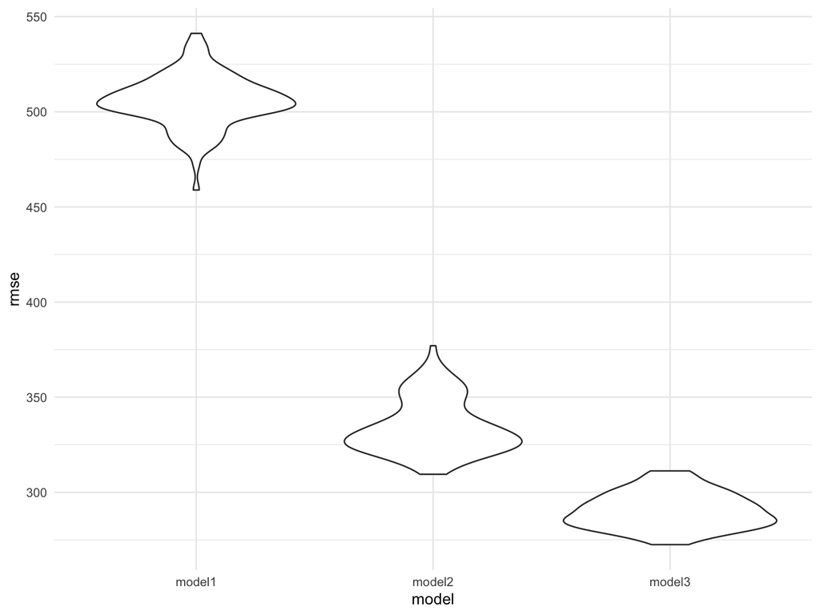

```r
cv_df %>%
  select(starts_with("rmse")) %>%
  pivot_longer(
    everything(),
    names_to = "model",
    values_to = "rmse",
    names_prefix = "rmse_") %>%
  mutate(model = fct_inorder(model)) %>%
  ggplot(aes(x = model, y = rmse)) + geom_violin()
```

From the plot of models against rmse, we see that model3 is the best fit model, followed by model2, and then model1.

## Problem 2

Load the data

```r
weather_df =
  rnoaa::meteo_pull_monitors(
    c("USW00094728"),
    var = c("PRCP", "TMIN", "TMAX"),
    date_min = "2017-01-01",
    date_max = "2017-12-31") %>%
  mutate(
    name = recode(id, USW00094728 = "CentralPark_NY"),
    tmin = tmin / 10,
    tmax = tmax / 10) %>%
  select(name, id, everything())
```

```
## using cached file: ~/Library/Caches/R/noaa_ghcnd/USW00094728.dly
```

```
## date created (size, mb): 2021-10-04 19:51:16 (7.602)
```

```
## file min/max dates: 1869-01-01 / 2021-10-31
```

Create function to generate bootstrap samples and check to see if it’s working.

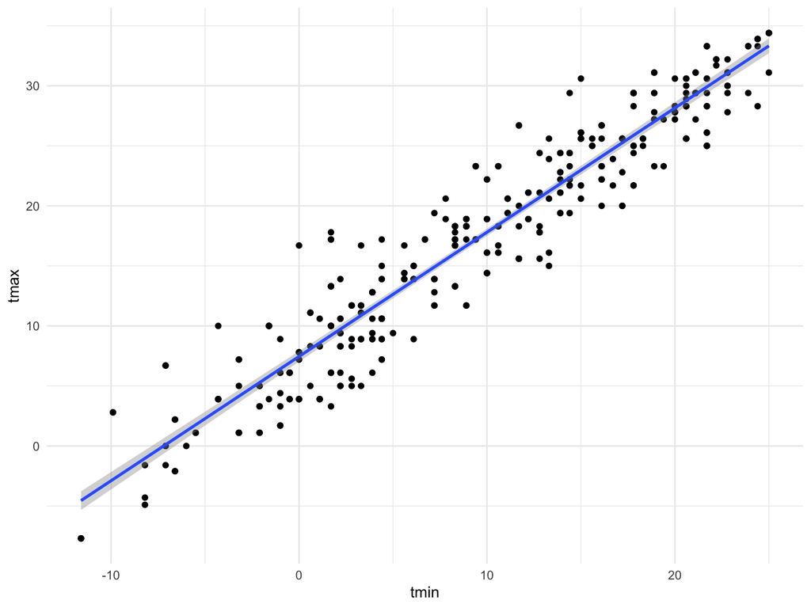

```r
set.seed(1)

boot_sample = function(df) {
  sample_frac(df, replace = TRUE)
}


boot_sample(weather_df) %>%
  ggplot(aes(x = tmin, y = tmax)) +
  geom_point() +
  stat_smooth(method = "lm")
```

Draw 5000 bootstrap samples

```r
boot_straps =
  data_frame(
    strap_number = 1:5000,
    strap_sample = rerun(5000, boot_sample(weather_df))
  )
```

Create bootstrap results.

```r
bootstrap_results =
  boot_straps %>%
  mutate(
    models = map(strap_sample, ~lm(tmax ~ tmin, data = .x)),
    results = map(models, broom::tidy)) %>%
  select(-strap_sample, -models) %>%
  unnest(results)

bootstrap_results_r =
  boot_straps %>%
  mutate(
    models = map(strap_sample, ~lm(tmax ~ tmin, data = .x)),
    results = map(models, broom::glance)) %>%
  select(-strap_sample, -models) %>%
  unnest(results) %>%
  select(strap_number, r.squared)

bootstrap_results_log =
  bootstrap_results %>%
    mutate(log_estimate = log(estimate)) %>%
    group_by(strap_number) %>%
    summarise(log_b0b1 = sum(log_estimate))

bootstrap_results_final =
  merge(bootstrap_results_r, bootstrap_results_log, by = "strap_number")
```

```r
plot_rsq =
  bootstrap_results_final %>%
  ggplot(aes(x = r.squared)) +
  geom_density(size = 1) +
  labs(
    title = "Plot of R-sqaured distribution"
  )

plot_log =
  bootstrap_results_final %>%
  ggplot(aes(x = log_b0b1)) +
  geom_density(size = 1) +
  labs(
    title = "Plot of log(b0*b1) distribution"
  )
```

*Identify confidence intervals:*

```r
ci_rsq =
  bootstrap_results_final %>%
  pull(r.squared) %>%
  quantile(., probs = c(0.025, 0.975), na.rm = TRUE)

ci_log =
  bootstrap_results_final %>%
  pull(log_b0b1) %>%
  quantile(., probs = c(0.025, 0.975), na.rm = TRUE)
```

For *R-squared*, the 95% C.I. is 0.8938 to 0.9271. For *log(b0b1)*, the 95% C.I. is 1.9659 to 2.0604.